# COVID-19 situations of Japan post 2

Exploring the additional information of COVID-19 in Japan

Jinhao Luo

2020-09-18

# 1 Introduction

As mention in the [first blog post](https://etc5523-jinhao-blog-post.netlify.app/post/covid_19_japan/etc5523-blog-1/) last two weeks ago, Japan has experienced the second outbreak from July 2020, which would generate some negative influences to the country. But how is the situation of COVID-19 in Japan developing for the past two weeks. Therefore, this post will continue to focus on tracking the cases of COVID-19 in Japan based on the first post. However, the first post only use the statistical tables to support the analysis, which might not be sufficient and comprehensive. Therefore, this post will create some plots to illustrate the pandemic in Japan to show clearer trends and compare.

This post will focus on the overall situation of COVID-19 in Japan first, to identify the general trends of total confirmed cases, total recovered cases, as well as the total mortality in order to evaluate the current condition. After that, the post will go further to analysis the pandemic trend of each city in Japan, as well as make the compare in order to filter out the most serious area in Japan.

# 2 Data stories

## 2.1 The overall situation of COVID-19 in Japan

Figure @ref(fig:cumulative-plot) shows the trends of the total confirmed, recovered, and death cases of Japan from the first patient has been confirmed to 16/09/2020. It is clear that the total confirmed cases and recovered case have the similar trend during the time period. While, the trend of total death cases is flat, which should be a fortunate condition in this pandemic. The first outbreak happens in 01/04, which has experienced an significant increase from around 5000 confirmed cases to around 15000 cases in a month. After that the trend changed to be moderate, which seems likely that the pandemic has been controlled. Many patients have recovered since 01/05. The total recovered cases increased dramatically until 01/06, which has recorded around 15000 persons.

However, two months later, Japan has experienced the second outbreak of COVID-19. The trend of total confirmed cases has changed, and experienced a rapid rise since 01/07. Until 16/09, the total confirmed cases have recorded over 75000 persons. This increase was more significant and longer than the first one. However, it is clear that, the total recovered rate also follow the similar trend of the total confirmed cases in the second outbreak, which might indicated that the medical system and therapy of Japan have sufficient abilities to handle COVID-19, and hospital could help patients to recover as soon as possible.

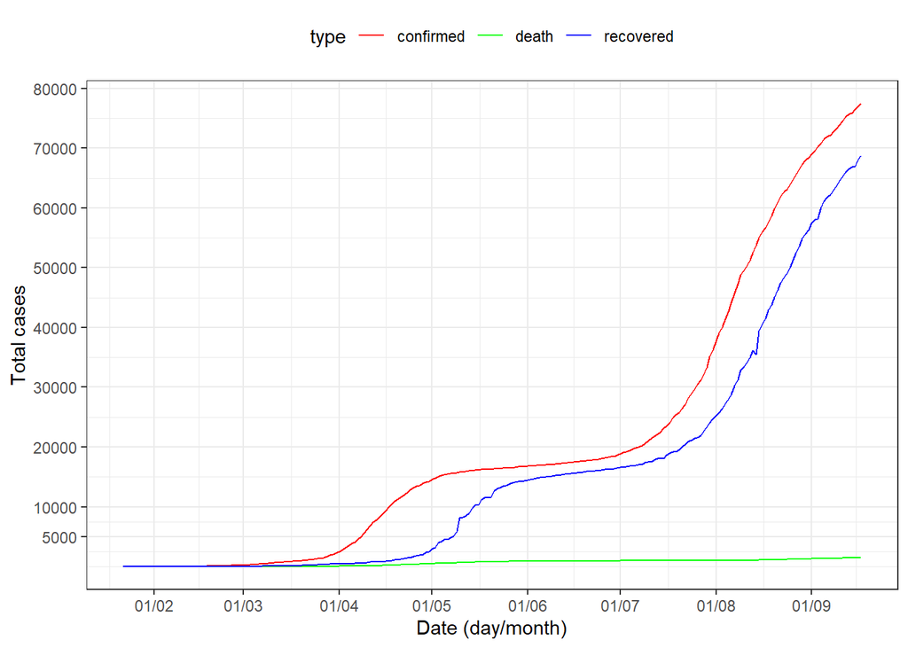

(#fig:cumulative-plot)Total confirmed, recovered, and deadth cases of COVID-19 in Japan (22/01/2020-16/09/2020)

## 2.2 COVID-19 situation of cities in Japan

Figure @ref(fig:top-six-plot) shows the COVID-19 condition of the first six highest confirmed cases cities in Japan. However, by browsing that plot, and compared with the Figure @ref(fig:cumulative-plot), we found that the figures of Figure @ref(fig:top-six-plot) since June might not be credible because the trend of all cases never changed, while the total cases have still experienced a increasing trend in Japan. Therefore, the section would only focus on the first outbreak of COVID-19 in Japan, which was the period from January to May.

Tokyo has accounted for the highest total confirmed cases among the six cities, which may be the high dimension of population in Tokyo city. In addition, Osaka is the city with the second highest total confirmed cases which were almost 2000 persons. While, the rest countries have the similar total confirmed cases which were around 1000 persons.

In addition, Osaka, Kanagawa, Hokkaido, Saitama, and Chiba have the similar total mortality which were less than 500 persons. Tokyo, however, has the highest mortality because of the highest confirmed cases. Furthermore, Tokyo and Osaka were the two city with the highest recovery rate which were aound 3600 and 1400, respectively. City of Kanagawa and Saitama have the similar recovered cases which were around 1000 persons. While, city of Chiba and Hokkaido have accounted for the least recovery rate which was over 500 persons during the five-month period.

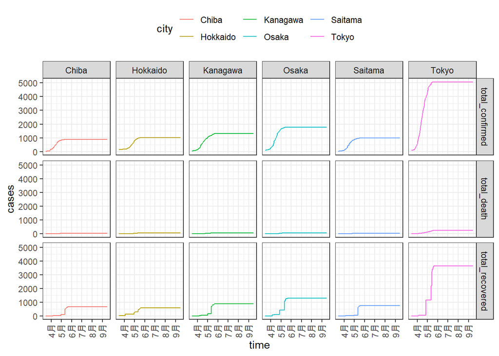

(#fig:top-six-plot)Total confirmed, recovered, and death cases of COVID-19 of the first six highest confirmed cases cities (15/03/2020-13/09/2020)

# 3 Conclusions

In general, Japan has still experienced the increasing trends of confirmed cases. However, the daily recovery rate has overtaken the daily confirmed cases since the middle of August, which might show a positive information because the recovered people were more than the confirmed patients. It might implicated that Japan was experiencing the process of recovery. In addition, Tokyo and Osaka were the most serious cities in the first outbreak of COVID-19. Although the city of Kanagawa, Hokkaido, Saitama, and Chiba also accounted for the first six highest confirmed case, the confirmed, and death cases were low compared with the top two cities.

# 4 Acknowledgement

This post has used two dataset for carrying out the analysis. The first one is from coronavirus package, which is used for doing the general trends evaluation of COVID-19 in Japan. And the second one is from nCov2019 package, which is used for analysing the COVID-19 condition of cities in Japan. Click the link and you can get more details from the websites.

The programming language used to write the data stories of COVID-19 in Japan is R (4.0.2) (R Core Team 2020). Following packages has been included in the scripts:

- package tidyverse (1.3.0) (Wickham et al. 2019),
- package ggplot2 (3.3.2) (Wickham 2016),
- package dplyr (1.0.1) (Wickham et al. 2020),
- package plotly (4.9.2.1) (Sievert 2020),
- package lubridate (1.7.9) (Grolemund and Wickham 2011),
- package DT (0.15) (Xie, Cheng, and Tan 2020),
- package widgetframe (0.3.1) (Karambelkar 2017),
- package htmltools (0.5.0) (Cheng et al. 2020),
- package coronavirus (0.3.0) (Krispin and Byrnes 2020),
- package nCov2019 (0.3.6) (Yu 2020)

# References

Cheng, Joe, Carson Sievert, Winston Chang, Yihui Xie, and Jeff Allen. 2020. *Htmltools: Tools for Html*. https://CRAN.R-project.org/package=htmltools.

Grolemund, Garrett, and Hadley Wickham. 2011. “Dates and Times Made Easy with lubridate.” *Journal of Statistical Software* 40 (3): 1–25. http://www.jstatsoft.org/v40/i03/.

Karambelkar, Bhaskar. 2017. *Widgetframe: ’Htmlwidgets’ in Responsive ’Iframes’*. https://CRAN.R-project.org/package=widgetframe.

Krispin, Rami, and Jarrett Byrnes. 2020. *Coronavirus: The 2019 Novel Coronavirus Covid-19 (2019-nCoV) Dataset*. https://CRAN.R-project.org/package=coronavirus.

R Core Team. 2020. *R: A Language and Environment for Statistical Computing*. Vienna, Austria: R Foundation for Statistical Computing. https://www.R-project.org/.

Sievert, Carson. 2020. *Interactive Web-Based Data Visualization with R, Plotly, and Shiny*. Chapman; Hall/CRC. https://plotly-r.com.

Wickham, Hadley. 2016. *Ggplot2: Elegant Graphics for Data Analysis*. Springer-Verlag New York. https://ggplot2.tidyverse.org.

Wickham, Hadley, Mara Averick, Jennifer Bryan, Winston Chang, Lucy D’Agostino McGowan, Romain François, Garrett Grolemund, et al. 2019. “Welcome to the tidyverse.” *Journal of Open Source Software* 4 (43): 1686. https://doi.org/10.21105/joss.01686.

Xie, Yihui, Joe Cheng, and Xianying Tan. 2020. *DT: A Wrapper of the Javascript Library ’Datatables’*. https://CRAN.R-project.org/package=DT.

Yu, Guangchuang. 2020. *NCov2019: Stats of the ’2019-nCov’ Cases*.